# PCIT-CoS-Waitlist RCT Paper 1: SSP Disorganisation

Nancy Briggs

2024-06-12

### SSP Disorganisation

Output run on 2024-06-12

variables are ssp_pre_four_way_organized_or_disorganized & ssp_post_four_way_organized_or_disorganized

#### Descriptives

| group | time | 0 | pct0 | 1 | pct1 | total |
| --- | --- | --- | --- | --- | --- | --- |
| 1 | Pre | 10 | 0.345 | 19 | 0.655 | 29 |
| 2 | Pre | 16 | 0.552 | 13 | 0.448 | 29 |
| 3 | Pre | 15 | 0.517 | 14 | 0.483 | 29 |
| 1 | Post | 9 | 0.600 | 6 | 0.400 | 15 |
| 2 | Post | 3 | 0.750 | 1 | 0.250 | 4 |
| 3 | Post | 1 | NA | NA | NA | NA |

#### Model & Results

A generalized linear mixed model (GLMM) with random effect for individual and fixed effects of group, time and the interaction was run. A binomial distribution with logit link was specified. Odds ratios were obtained for group differences and change within group.

```
## fixed-effect model matrix is rank deficient so dropping 1 column / coefficient
```

[output not shown]

This is the ANOVA table for the model. p-values are likelihood ratio tests for adding the new term to the model just before. A p-value <0.05 indicates that adding that term results in better model fit. The most important p-value is the interaction p-value. Here, there is no evidence that the pattern of change over time is different among the groups (p=0.782).

```r
summary(result3)
```

```
## Generalized linear mixed model fit by maximum likelihood (Laplace
##   Approximation) [glmerMod]
##  Family: binomial  ( logit )
## Formula: outcome ~ group * time + (1 | id)
##    Data: dat
##
##      AIC      BIC   logLik deviance df.resid
##    153.2    169.1    -70.6    141.2      100
##
## Scaled residuals:
##      Min       1Q   Median       3Q      Max
## -1.43054 -0.79844  0.01393  0.88820  1.50610
##
## Random effects:
##  Groups Name        Variance Std.Dev.
##  id     (Intercept) 0.7241   0.8509
## Number of obs: 106, groups:  id, 87
##
## Fixed effects:
##              Estimate Std. Error z value Pr(>|z|)
## (Intercept)    0.7603     0.4781   1.590    0.112
## group2        -1.0067     0.6618  -1.521    0.128
## group3        -0.8425     0.6513  -1.294    0.196
## time2         -1.1663     0.7456  -1.564    0.118
## group2:time2   0.4369     1.5624   0.280    0.780
##
## Correlation of Fixed Effects:
##             (Intr) group2 group3 time2
## group2      -0.748
## group3      -0.743  0.558
## time2       -0.574  0.432  0.428
## group2:tim2  0.319 -0.409 -0.241 -0.507
## fit warnings:
## fixed-effect model matrix is rank deficient so dropping 1 column / coefficient
```

#### Estimated Means & Change

Estimated means for each Treatment and Time are presented. In addition, within-group change between time points is presented with 95% CIs.

##### Group ORs at each timepoint

Odds Ratios at Each Time Point

| Comparison | Time | OR | SE | z | p | adj p | Lower CL | Upper CL |
| --- | --- | --- | --- | --- | --- | --- | --- | --- |
| 1 / 2 | 1 | 2.737 | 1.811 | 1.521 | 0.281 | 0.385 | 0.580 | 12.908 |
| 1 / 3 | 1 | 2.322 | 1.512 | 1.294 | 0.399 | 0.587 | 0.505 | 10.686 |
| 2 / 3 | 1 | 0.849 | 0.524 | -0.266 | 0.962 | 1.000 | 0.200 | 3.606 |
| 1 / 2 | 2 | 1.768 | 2.521 | 0.400 | 0.916 | 1.000 | 0.062 | 50.009 |
| 1 / 3 | 2 | NA | NA | NA | NA | NA | NA | NA |
| 2 / 3 | 2 | NA | NA | NA | NA | NA | NA | NA |

In this table the OR is the effect size. No bootstrapping is needed.

At t1, the OR for G1 vs G2 is 2.737.

At t1, the OR for G1 vs G3 is 2.322.

At t1, the OR for G2 vs G3 is 0.849.

None of the pvalues < 0.05.

##### Change within each group

Within-Group Change

| Comparison | Group | OR | SE | z | p | adj p | Lower CL | Upper CL |
| --- | --- | --- | --- | --- | --- | --- | --- | --- |
| 2 / 1 | 1 | 0.312 | 0.232 | -1.564 | 0.118 | 0.118 | 0.072 | 1.343 |
| 2 / 1 | 2 | 0.482 | 0.650 | -0.541 | 0.588 | 0.588 | 0.034 | 6.766 |
| 2 / 1 | 3 | NA | NA | NA | NA | NA | NA | NA |

These ORs now represent the odds of a 1 at time 2 relative to time 1 within group. Because there is only 1 comparison within group, the adjusted pvalue is the same.

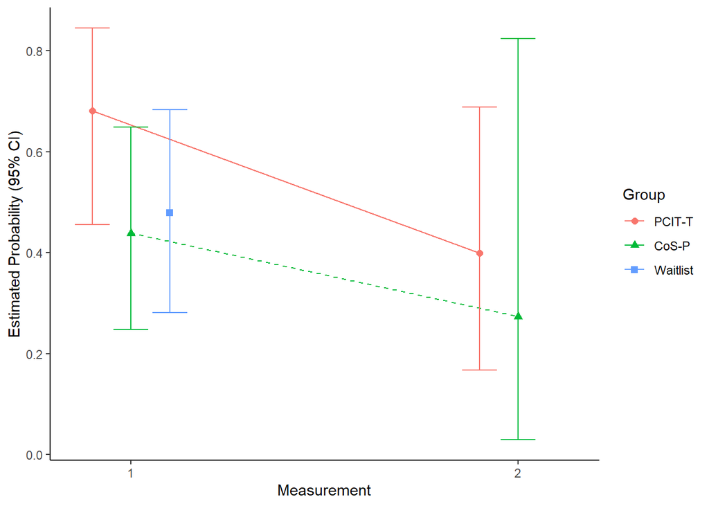

#### Hypothesis 2

##### Difference between G1 and G2, change from T1 to T3

```
## group = 1:
##  time   prob    SE  df asymp.LCL asymp.UCL
##  1     0.681 0.104 Inf    0.4559     0.845
##  2     0.400 0.147 Inf    0.1671     0.689
##
## group = 2:
##  time   prob    SE  df asymp.LCL asymp.UCL
##  1     0.439 0.108 Inf    0.2483     0.649
##  2     0.274 0.256 Inf    0.0293     0.825
##
## group = 3:
##  time   prob    SE  df asymp.LCL asymp.UCL
##  1     0.479 0.109 Inf    0.2817     0.684
##  2    nonEst    NA  NA        NA        NA
##
## Confidence level used: 0.95
## Intervals are back-transformed from the logit scale
```

```
## group = 1:
##  contrast odds.ratio    SE  df asymp.LCL asymp.UCL
##  2 / 1         0.312 0.232 Inf    0.0723      1.34
##
## group = 2:
##  contrast odds.ratio    SE  df asymp.LCL asymp.UCL
##  2 / 1         0.482 0.650 Inf    0.0344      6.77
##
## group = 3:
##  contrast odds.ratio    SE  df asymp.LCL asymp.UCL
##  2 / 1        nonEst    NA  NA        NA        NA
##
## Confidence level used: 0.95
## Intervals are back-transformed from the log odds ratio scale
```

```
##
##   Simultaneous Tests for General Linear Hypotheses
##
## Fit: glmer(formula = outcome ~ group * time + (1 | id), data = dat,
##     family = binomial)
##
## Linear Hypotheses:
##        Estimate Std. Error z value Pr(>|z|)
## 1 == 0   0.4369     1.5624    0.28     0.78
## (Adjusted p values reported -- single-step method)
```

Change in G1 from T1 to T3: 0.312

Change in G2 from T1 to T3: 0.482

p=0.7803. We have no evidence that the change from T1 to T3 is different for G1 and G2

#### Residuals

Assumptions of the model are met.

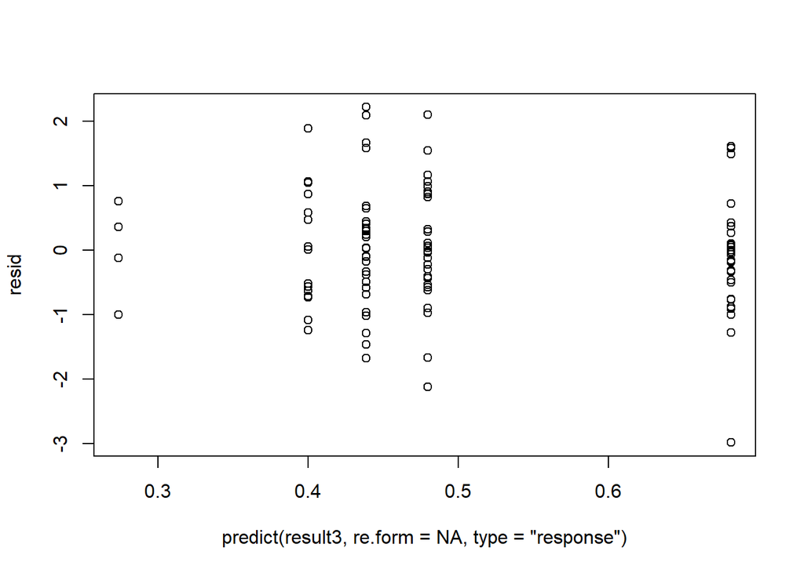

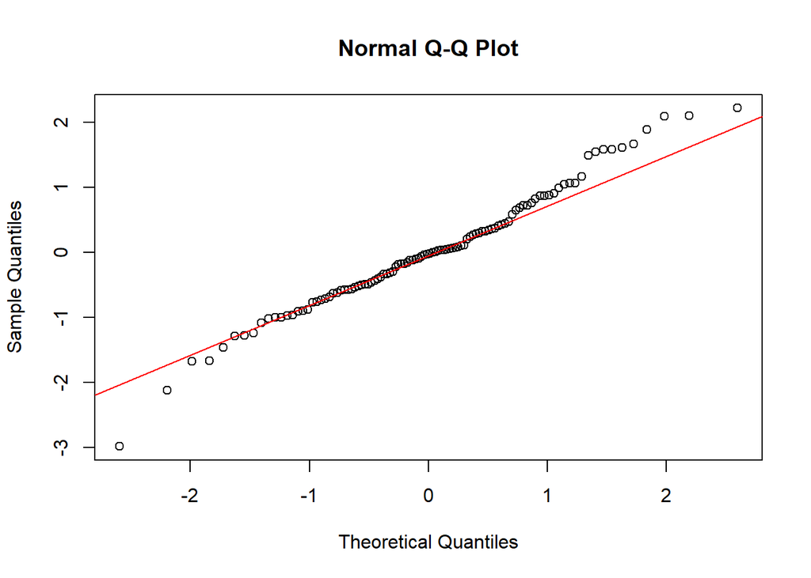

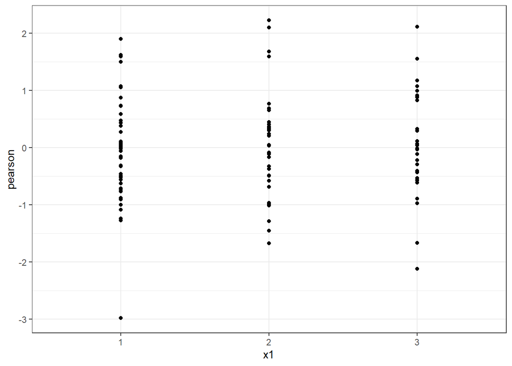

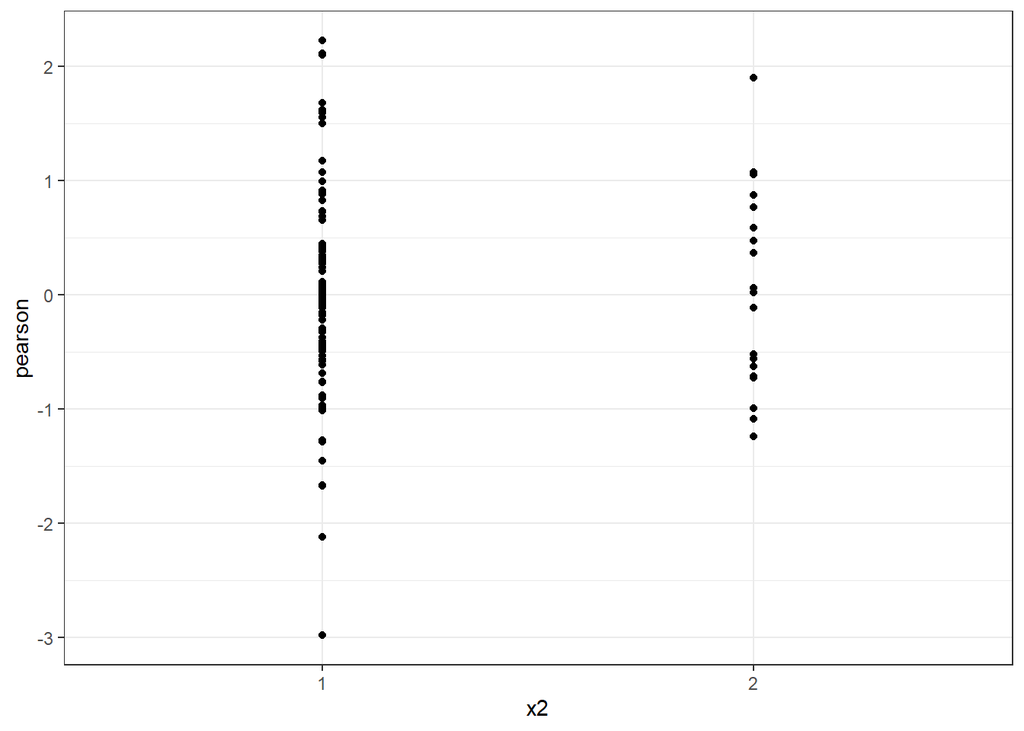

```r
rm(list = ls())
```